# A Proportional Odds Model with Cure with Application to Prostate Cancer

Fan Wu

2016-04-28

## Table of Contents

- Introduction
- Method
- The E-M Algorithm
- Application
- Conclusion

## Introduction

The prostate cancer data were extracted from [Surveillance, Epidemiology, and End Results (SEER) registries](http://seer.cancer.gov). The cohort consisted of men diagnosed with prostate cancer in the state of Utah before 1988. The survival outcome is the time (in months) from diagnosis to death, and we are interested in whether the time to event is associated with the stage of the cancer (localized, regional or distant).

In the presence of possible cure, to allow for non-proportionality on the hazard funcitons, we are going to consider a relatively flexible survival model in this analysis. Let $G(t|Z)$ denote the survival function for a subject with characteristic $Z \in \mathbb{R}^p$. Suppose the covariates affects enter the survival model through two parameters $\eta(Z)$ and $\theta(Z)$. A model with a cure we considered in Homework 1 is given by \begin{equation} \newcommand{\calL}{\mathcal{L}} \newcommand{\eH}{e^{-H}} G(t|Z) = \mathcal{L}(H) = \left\{\frac{\theta(Z)}{\theta(Z) + 1 - e^{-H(t)}}\right\}^{\eta(Z)}, \label{model} \end{equation}

where $H(t)$ is an arbitrary non-decreasing function such that $H(0) = 0$.

## Method

In Homework 1, we have shown that the survival function given by \begin{equation} \left\{\frac{\theta(Z)}{\theta(Z) + H(t)}\right\}^{\eta(Z)}, \label{model0} \end{equation}

is a complete monotonic (CM) function of $H$. Since $\eqref{model}$ is a composite of $\eqref{model0}$ and $\psi(H) = 1 - e^{-H}$, and that $\psi^{\prime}(H) = e^{-H}$ is CM, by the criteria for CM functions in Lecture 8, $\mathcal{L}(H)$ is a CM function of $H$. It is easy to see that $\mathcal{L}(0) = 1$; thus, $\mathcal{L}(\cdot)$ is a Laplace transform, and $\eqref{model}$ belongs to the proportional hazards frailty model (PHFM). Let $U$ denote the frailty, then $\calL(H) = \exp(-U \cdot H)$. Direct calculation also yields

\begin{align*} \log \calL & = \eta \log \theta - \eta \log(\theta + 1 - e^{-H}); \\ \log (-\calL^{\prime}) & = (\eta + 1) \{ \log \theta - \log (\theta + 1 - e^{-H})\} + \log (\eta/\theta) - H, \end{align*} and thus the posterior risks for $U$ for censored ($\delta = 0$) and failure ($\delta = 1$) event are \begin{align} \newcommand{\E}{\mathbb{E}} \newcommand{\THO}{\Theta^{(0)}} \newcommand{\THI}{\Theta^{(1)}} \newcommand{\THd}[1]{\Theta^{(\delta_{#1})}} \E(U|\delta = 0) = \THO & = -(\log \calL)^{\prime} = \frac{\eta \eH}{\theta + 1 - \eH}; \label{eq:TH0} \\ \E(U|\delta = 1) = \THI & = -\{\log (-\calL^{\prime})\}^{\prime} = \frac{(\eta + 1)\eH}{\theta + 1 - \eH} + 1. \label{eq:TH1} \end{align}

## The E-M Algorithm

- E-Step: Compute $\THd{i}$ using $\eqref{eq:TH0}$ and $\eqref{eq:TH1}$ for each subject $i$;
- M-Step: Maximize the complete Cox likelihood with frailty $U_i$ replaced by $\THd{i}$.
  - Using NPMLE, get the Breslow-type estimator $\hat{H}(\beta)$:
    $$\Delta \hat{H}_i^{(m+1)}(\beta) = \frac{d_i}{\sum_{j \in \mathcal{R}_i} \THd{j}(H_i^{(m)}(\beta))}$$
  - Plug $\hat{H}$ into the complete likelihood to get the profile likelihood $\ell_{pr}(\hat{H}(\beta), \beta)$, then maximize $\ell_{pr}$ to get $\hat{\beta}$. Alternatively, we can treat the estimated $\hat{H}$ as known and update $\beta$ by one Newton-Raphson step (this is what we tried).

The above algorithm in implemented in `R`.

## Application

### Preliminary Analysis

A total of 11621 prostate cancer patients were included in the study, of which 1032 experienced the event during the follow-up (censoring rate was 91%). The cancer for each patient were categorized into three stages in the order of sererity: local ($n$ = 9052), regional ($n$ = 1713) or distant ($n$ = 856). We plotted the Kaplan-Meier survival estiamtes as well as the fitted curve from the Cox model. It seems the survival for patients in the first two categories are much better than that in the ‘distant’ group. Comparing the non-parametric fit and the Cox fit, some deviation from the propotionality is suggested, since the KM curves for all stages seems to level off somewhat instead of decreasing steadily as demonstrated by the Cox fitted curves. A more flexible model with could be account for the possible cure and the non-proportionality might be a better fit.

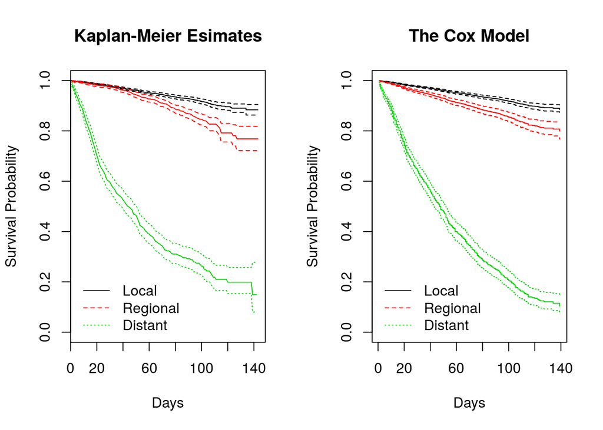

### A Proportional Odds Model with Cure (POC)

We coded a proportional odds model with cure in `R` to implement a simplified version of model $\eqref{model}$ where $\eta(Z) \equiv 1$. Unfortunately, we did not get the algorithm converge to a reasonable estimate up to now. The annoted `R` code and corresponding derivation are displayed instead.

The whole algorithm is implemented using four functions: `Theta1()` for the posterior risk evaluation; `dH1()` for updating the jumps in the baseline cumulative hazard function $H$; `Betas1()` for updating the regression coefficients $\beta_1$ with one Newton-Raphson step; and `POC1()` for combining all aforementioned functions into a loop.

Throughout the functions, we will use `Xs` to denote the vector of the observed survival times $X_i$’s; `Ds` the corresponding censoring indicators ($\delta_i = 1$ if the event was observed); `Z` the covariates matrix (two columns of dummy variables); `b1` the current value of $\beta_1$ (including the intercept); and `h` the current value of the jumps of $H$. We also have an auxilary function `get.inds()` to generate some indicators used for calculating the risk sets:

```r
get.inds <- function(Xs, Ds){
  n <- length(Xs)
  Ws <-  unique(Xs[Ds == 1])
  m <- length(Ws)
  list(ind0 = outer(Ws, Xs, "=="),
       inda = outer(Ws, Xs, "<="))
}
```

Here, `Ws` are the distinct observed event times $w_k, k = 1, \dot, K$, with length `m`. The result from this function are two matrice of 0-1 indices. `ind0` indexes the place of the event times, whereas `inda` gives the risk set at each $w_k$.

#### The Posterior Risks

```r
Theta1 <- function(Xs, Ds, inda, Z, b1, h){
  # sample size
  n <- length(Xs)
  # augmenting the covariate matrix with a column of 1's
  Z1 <- cbind(1, Z)
  # distinct observed event times
  Ws <- unique(Xs[Ds == 1])
  # number of distinct observed event times
  m <- length(Ws)
  # ids for the last event time
  ids.Wm <- which(Xs == Ws[m] & Ds == 1)
  # ids for the last censored times
  ids.C <- (max(ids.Wm) + 1) : n
  # cumulative baseline hazard function evaluated at each observed survival time
  hh <- inda[-m, ] * h
  H <- colSums(hh)
  # baseline survival function for the last but one failure time
  Fl <-  exp(-max(H))
  # predictor values, exp(b0 + b1 * Z)
  theta <- as.numeric(exp(Z1 %*% b1))
  theta.Wm <- theta[ids.Wm]
  # posterior risks for each subject
  Theta <- (1 + Ds) * exp(-H) / (theta + 1 - exp(-H)) + Ds
  Theta[ids.Wm] <- (theta.Wm + 1) / (theta.Wm + 1 - Fl)
  Theta[ids.C] <- 0
  Theta
}
```

The augmented covariates matrix `Z1` is used to account for the intercept. To facilitate the correction for the $\THd{i}$, we use `ids.Wm` and `ids.C` to extract the corresonding indice which will be updated later. $H$ is evaluate at each subject’s observed survival times; $H(X_i) = \sum_k I(X_i \geqslant s_k) h_k$. `Fl` gives the survival jump for the last observation $F_l$. The posterior risks for each subject are given by $\eqref{eq:TH0}$ and $\eqref{eq:TH1}$ (with $\eta = 1$). The following two lines update the $\THd{i}$ using [^1] [^2] [^3]
$$\frac{\gamma^{\prime}(F_l|Z_i) F_l}{\gamma(F_l|Z_i) - \gamma(0|Z_i)} = \frac{\theta + 1}{\theta + 1 - F_l}$$
for the last failure and zero for all the rest censored observations.

#### The Jumps of the Baseline Cumulative Hazard Function

```r
dH1 <- function(ind0, inda, Xs, Ds, Z, b1, h){
  m <- length(h) + 1
  nd <- rowSums(ind0)[-m]
  post.risk <- Theta1(Xs, Ds, inda, Z, b1, h)
  nd / as.numeric(inda[-m, ] %*% post.risk)
}
```

This function calls `Theta1()` to calculate the posterior risks. The second line calculate the number of events at each $w_k$, and the denominator in the last line gives the summation over the risk set at time $w_k$.

#### The Newton-Raphson Update for $\beta_1$

```r
Betas1 <- function(inda, Xs, Ds, Z, b1, h){
  n <- length(Xs)
  Z1 <- cbind(1, Z)
  Ws <- unique(Xs[Ds == 1])
  m <- length(Ws)
  # ids of the last failure and last censored
  ids.Wm <- which(Xs == Ws[m] & Ds == 1)
  ids.C <- (max(ids.Wm) + 1) : n
  # the cumulative baseline hazard (correct up to the last failure)
  hh <- inda[-m, ] * h
  H <- colSums(hh)
  # baseline survival at the last but one failure
  Fl <-  exp(-max(H))
  # predictor exp(b0 + b1 * Z)
  theta <- as.numeric(exp(Z1 %*% b1))
  theta.Wm <- theta[ids.Wm]
  theta.C <- theta[ids.C]
  # survival for each subject
  G <- theta / (theta + 1 - exp(-H))
  G_ <- 1 - G
  # survival for the last but one failure
  Gl <- theta.Wm / (theta.Wm + 1 - Fl)
  Gl_ <- 1 - Gl
  # survival for the last failure
  Gm <- (theta.Wm / (theta.Wm + 1))
  Gm_ <- 1 - Gm
  # score coeff for each subject
  U1. <- G_ - Ds * G
  # modify the score coeff for the last failure and censored subjects
  U1.[ids.Wm] <- (Gl * Gl_ - Gm * Gm_) / (Gl - Gm)
  if( is.nan(U1.[ids.Wm]) ) U1.[ids.Wm] <- 0
  U1.[ids.C] <- 1 / (theta.C + 1)
  # score
  U1 <- t(U1.) %*% Z1
  # Fisher.inv coeff for each subject
  J11. <- (1 + Ds) * G * G_
  # modify the Fisher.inv coeff for the last failure and censored subjects
  J11.[ids.Wm] <- (Gm * Gm_ * (Gm_ - Gm) - Gl * Gl_ * (Gl_ - Gl)) /
                  (Gl - Gm) + U1.[ids.Wm] ^ 2
  if( is.nan(J11.[ids.Wm]) ) J11.[ids.Wm] <- 0
  J11.[ids.C] <- theta.C / (1 + theta.C) ^ 2
  # Fisher.inv
  J11 <- crossprod(J11. * Z1, Z1)
  # N-R update
  as.numeric(b1 + solve(J11) %*% c(U1))
}
```

This function also works similarly to `Theta1()`, where we first define the general format score or inversed Fisher information for each subject then correct it at the corresponding indice `ids.Wm` (the last failure) and `ids.C` (all the tailing censored ones). Note that we added two lines to avoid `Inf` values of the score/inverse Fisher for the last jump (this `Inf` could be due to a bug in the code).

The general score for all subject is given by
$$\frac{\partial\ell}{\partial\beta_1} = \sum_i (\bar{G}_i - \delta_i G_i) \bar{Z}_i,$$
where $G_i = \theta_i / (\theta + 1 - F_i)$, $\bar{G}_i = 1 - G_i$ and $F_i = H(X_i)$. The general inverse Fisher information is
$$- \frac{\partial^2\ell}{\partial\beta_1^2} = \sum_i (1 + \delta_i) G_i \bar{G}_i \bar{Z}_i^{\otimes 2},$$
where we use the fact that $-\bar{G}_i^{\prime} = G_i^{\prime} = G_i \bar{G}_i \bar{Z}_i$.

The correct term for the contribution of the last failure is $\ell_m = \log(G_l - G_m)$, where $G_l = \theta / (\theta + 1 - F_l)$ and $G_m = \theta / (\theta + 1)$.

The corresponding derivatives are \begin{align} \frac{\partial\ell_m}{\partial\beta_1} & = \frac{G_l \bar{G}_l-G_m \bar{G}_m}{G_l - G_m} \bar{Z}_i; \\ -\frac{\partial^2\ell_m}{\partial\beta_1^2} & = \left\{\frac{G_m \bar{G}_m (\bar{G}_m - G_m) - G_l \bar{G}_l (\bar{G}_l - G_l)}{G_l - G_m} + \frac{\partial\ell_m}{\partial\beta_1} \right\} \bar{Z}_i^{\otimes 2}. \end{align}

The correct term for the contribution of the last censored observations are $\ell_c = \log(\theta / \theta + 1) = \log G_m$.

The corresponding derivatives are \begin{align} \frac{\partial\ell_c}{\partial\beta_1} & = \bar{G}_m \bar{Z}_i; \\ -\frac{\partial^2\ell_c}{\partial\beta_1^2} & = \bar{G}_m G_m \bar{Z}_i^{\otimes 2}. \end{align}

The Newton-Raphson updating step is given by the last line:
$$\beta_1^{(k+1)} = \beta_1^{(k)} + J^{-1} U.$$

#### The Function to Implement the Iteration

```r
POC1 <- function(ind0, inda, Xs, Ds, Z, b1, h, K = 30){
  p <- ncol(Z)
  b1.hat <- b1
  h.hat <- h
  diff <- 999
  k <- 0
  while(diff > 0.0005 & k <= K){
    k <- k + 1
    # Breslow
    h.hat.new = dH1(ind0 = ind0, inda = inda,
                   Xs = Xs, Ds = Ds, Z = Z,
                   b1 = b1.hat, h = h.hat)
    # N-R update one-step
    b1.hat.new = Betas1(inda = inda, Xs = Xs, Ds = Ds, Z = Z,
                      b1 = b1.hat, h = h.hat.new)
    diff = max(abs(c(b1.hat.new - b1.hat, h.hat.new - h.hat)))
    cat("Interation",k,"\n ========================== \n")
    cat(b1.hat,"\n",b1.hat.new,"\n", diff,"\n\n")
    b1.hat <-  b1.hat.new
    h.hat <- h.hat.new
  }
  list(b1.hat = b1.hat, h.hat = h.hat)
}
```

### The Results

The current POC model fitting `R` code converges, but to rather wierd results. `b1.hat` and `h.hat` gives the estimates for $\beta_1$ and $H\{w_k\}$, respectively.

```
## Interation 1
##  ==========================
## 0.4 -0.5 0.4
##  1.86248 -0.313789 -1.452576
##  11.13
##
## Interation 2
##  ==========================
## 1.86248 -0.313789 -1.452576
##  2.654106 -0.6628559 -2.22609
##  0.7916265
##
## Interation 3
##  ==========================
## 2.654106 -0.6628559 -2.22609
##  3.043997 -0.9684258 -2.610796
##  0.3898909
##
## Interation 4
##  ==========================
## 3.043997 -0.9684258 -2.610796
##  3.130488 -1.051866 -2.695092
##  0.08649064
##
## Interation 5
##  ==========================
## 3.130488 -1.051866 -2.695092
##  3.134321 -1.055651 -2.698443
##  0.00383321
##
## Interation 6
##  ==========================
## 3.134321 -1.055651 -2.698443
##  3.134352 -1.055677 -2.698422
##  6.582763e-05
```

```
## b1.hat
```

```
## [1]  3.134352 -1.055677 -2.698422
```

```
## h.hat
```

```
##   [1]  0.1428276  0.1690073  0.1295811  0.1439624  0.1075675  0.1486334
##   [7]  0.1458695  0.1509050  0.1917591  0.1592324  0.1927673  0.1859888
##  [13]  0.1739864  0.1759469  0.1626979  0.1700587  0.1638356  0.1814291
##  [19]  0.1768970  0.1933546  0.1972262  0.1907814  0.1951124  0.2140521
##  [25]  0.2247013  0.2408284  0.2085170  0.2206871  0.1915141  0.2281083
##  [31]  0.2503927  0.2640128  0.2509496  0.2514834  0.2995533  0.2393872
##  [37]  0.2403275  0.3004229  0.2409813  0.2689568  0.2085257  0.2330051
##  [43]  0.2219417  0.2628834  0.2401033  0.2560627  0.2534420  0.3048418
##  [49]  0.2976181  0.3183175  0.2153842  0.3164552  0.2727270  0.3617019
##  [55]  0.3259258  0.2585550  0.4186045  0.2639999  0.3999999  0.2857143
##  [61]  0.3260869  0.3721973  0.3686636  0.3239437  0.3155340  0.3550000
##  [67]  0.3641026  0.4594595  0.5028571  0.4470588  0.4790419  0.6603774
##  [73]  0.5496689  0.5135135  0.4500000  0.5073529  0.5079365  0.6033058
##  [79]  0.4786325  0.5840708  0.8971963  0.8514851  0.7300000  0.9791667
##  [85]  0.9444444  1.0224719  0.7906977  0.7560976  0.8461538  1.0131579
##  [91]  0.9863014  1.1267606  1.6176471  1.5000000  1.8793103  1.6181818
##  [97]  1.8076923  2.0833333  1.1276596  1.5116279  1.3250000  1.1794872
## [103]  1.6857143  1.3529412  1.4193548  1.8461538  1.8400000  2.0909091
## [109]  3.4500000  1.6666667  2.5625000  2.2142857  2.3076923  2.5000000
## [115]  3.1250000  5.0000000  5.1666667  2.6000000  7.0000000  6.3333333
## [121] 11.5000000
```

We plot the posterior risks $\THd{i}$ for all subjects, with failure events in red. Although the general trends look fine, but it seems they all decline too fast at the earlier follow-up time.

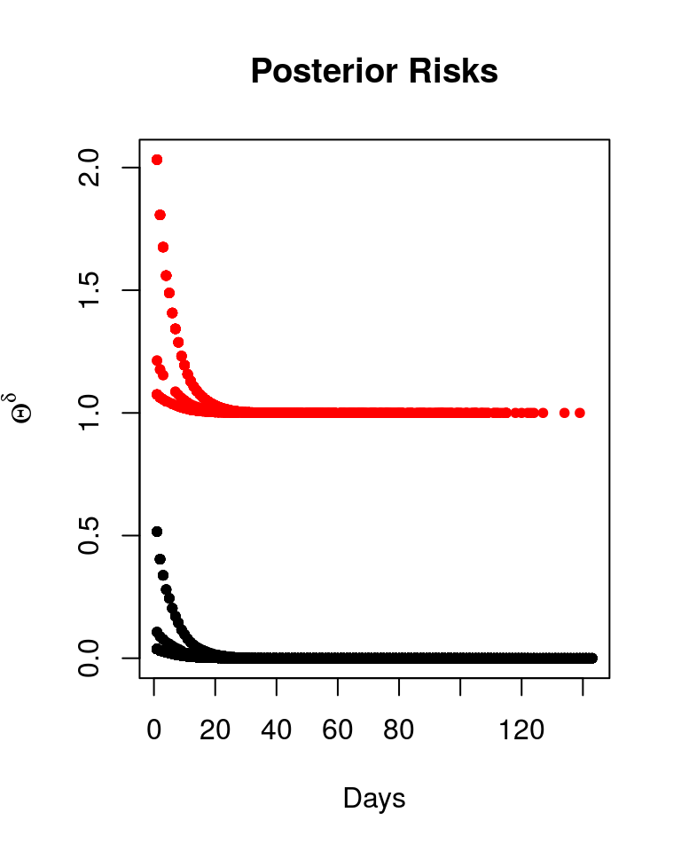

We also plot the fitted POC survival curve side-by-side with the KM curves, they are not like each other beside the relative positions of the curves.

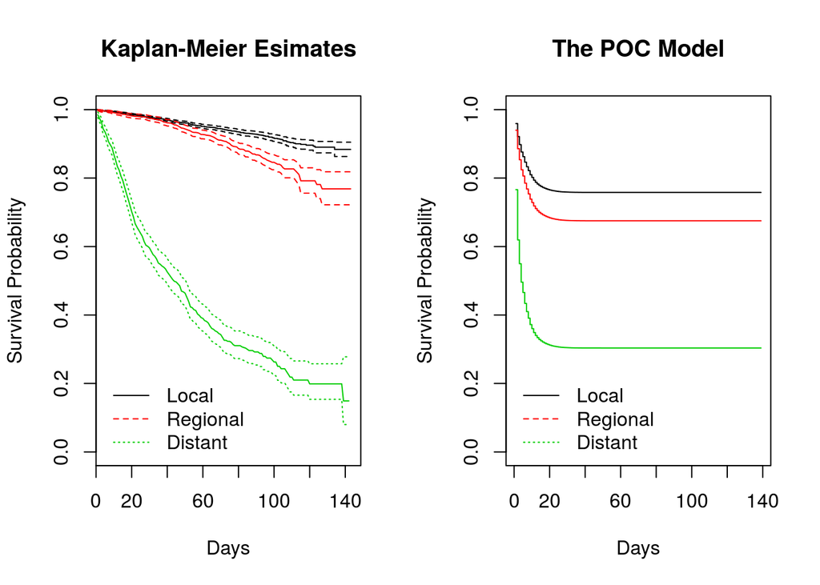

## Conclusion

The model $\eqref{model}$ belongs to the general nonlinear transformation models (NTMs), and should be able to fitted using the QEM algorithm. We did also tried the more general model with $\eta \neq 1$ and more restricted proportional odds model, but nothing converges so far. We will keep on debugging the current code to see it works one day. Both the theoretical properties and the numerical performance of the model are worth investigating further.

We also tried the deprecated `nltm` package in `R`, and the model fitting results for the proportional odds model looks fine, yet those for the gamma frailty model (a re-parameterization of $\eqref{model}$) also look wierd.

All the codes, including trials/errors and this report, are available on [GitHub](https://github.com/942kid/pocure).

```
## Authors: G. Garibotti, A. Tsodikov
```

```
## Authors: G. Garibotti, A. Tsodikov
## Call:
## nltm(formula1 = Surv(Xs, Ds) ~ Z, data = seer, nlt.model = "PO")
##
## Non Linear Transformation Model: PO, fit by maximum likelihood
##
##      coef exp(coef) se(coef)      z       p
## Z2 -0.581    0.5593   0.0925  -6.28 3.3e-10
## Z3 -3.409    0.0331   0.0893 -38.20 0.0e+00
##
##    exp(coef) exp(-coef) lower .95 upper .95
## Z2    0.5593       1.79    0.4666    0.6704
## Z3    0.0331      30.24    0.0278    0.0394
##
## Likelihood ratio test=1464 on 2 df, p=0
## n=11621
```

```
## Authors: G. Garibotti, A. Tsodikov
```

```
## Authors: G. Garibotti, A. Tsodikov
## Call:
## nltm(formula1 = Surv(Xs, Ds) ~ Z, data = seer, nlt.model = "GFM")
##
## Non Linear Transformation Model: GFM, fit by maximum likelihood
##
## Long term predictor
##     coef exp(coef) se(coef)      z    p
## Z2  4.47   87.3437    8.400  0.532 0.59
## Z3 -3.13    0.0439    0.318 -9.831 0.00
##
##    exp(coef) exp(-coef) lower .95 upper .95
## Z2   87.3437     0.0114  6.18e-06  1.24e+09
## Z3    0.0439    22.8014  2.35e-02  8.18e-02
##
## Short term predictor
##     coef exp(coef) se(coef)     z    p
## Z2 5.000    148.41    8.397 0.595 0.55
## Z3 0.197      1.22    0.223 0.883 0.38
##
##    exp(coef) exp(-coef) lower .95 upper .95
## Z2    148.41    0.00674  1.06e-05  2.08e+09
## Z3      1.22    0.82123  7.86e-01  1.89e+00
##
## Likelihood ratio test=1469 on 4 df, p=0
## n=11621
```

[^1]: Tsodikov, A. D. “Semi‐parametric models of long‐and short‐term survival: an application to the analysis of breast cancer survival in Utah by age and stage.” Statistics in medicine 21.6 (2002): 895-920.
[^2]: Tsodikov, A. D. “Semiparametric models: a generalized self‐consistency approach.” Journal of the Royal Statistical Society: Series B (Statistical Methodology) 65.3 (2003): 759-774.
[^3]: Tsodikov, A. D., Ibrahim, J. G., and Yakovlev, A. Y. “Estimating cure rates from survival data.” Journal of the American Statistical Association (2011).